# PROJET 1 : Caractéristiques des rendements logarithmiques des actions

Ce document RMarkdown a pour objectif d’apporter une explication approfondie des raisonnements et des interprétations réalisés dans le cadre de l’étude des caractéristiques des rendements logarithmiques des actions, en se concentrant particulièrement sur les séries temporelles `rte` et `rtt`.

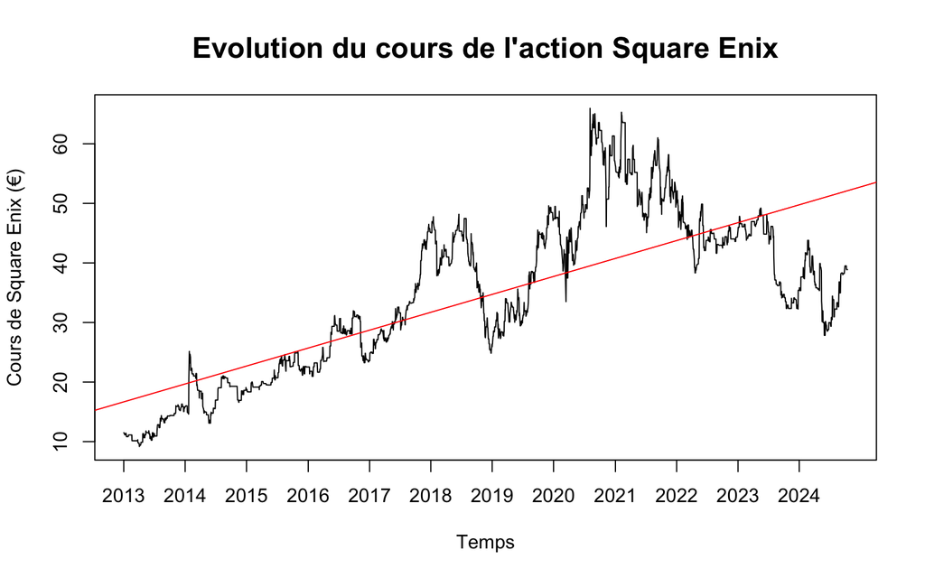

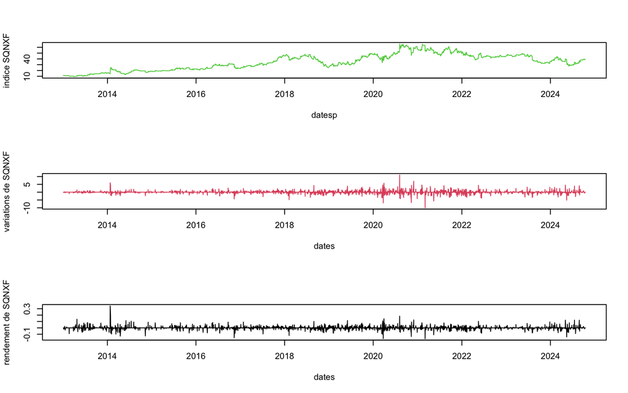

- Le premier graphique, montre que la série de l’action SQNXF a une tendance croissante ;
- Les deux autres graphiques, montrent que ses variations et son rendement logarithmique fluctuent autour de 0 ;
- De plus, pour dpt les fluctuations autour de 0 augmentent dans le temps, il semble y avoir plusieurs clusters de volatilité de 2020 à 2021 ainsi qu’en 2014.

# Étude des 8 caractéristiques la série rte

Voici le chronogramme de la série `rte` :

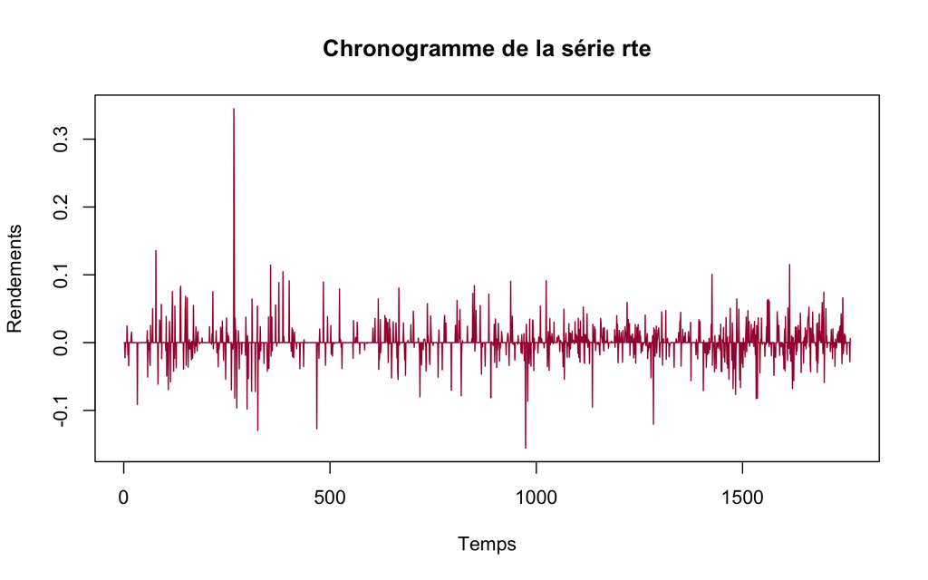

La série `rte` n’a visuellement pas l’air d’avoir de tendance, elle fluctue autour de 0. De plus, la variance ne semble pas non plus varier au cours du temps

## Propriété 1 : Asymétrie perte / gain

### Hypothèses

$H_0 : E\left[\left(\frac{X - E(X)}{\sigma_X}\right)^3\right] = 0 \quad VS \quad H_a : E\left[\left(\frac{X - E(X)}{\sigma_X}\right)^3\right] \neq 0$

### Cas pratique

```
##
##  D'Agostino skewness test
##
## data:  rte
## skew = 1.9953, z = 22.9046, p-value < 2.2e-16
## alternative hypothesis: data have a skewness
```

## Propriété 2 : Queues de distribution épaisses

### Hypothèses

$H_0 : E\left[\left(\frac{X - E(X)}{\sigma_X}\right)^4\right] = 3 \quad VS \quad H_a : E\left[\left(\frac{X - E(X)}{\sigma_X}\right)^4\right] \neq 3$

### Cas pratique

```
##
##  Anscombe-Glynn kurtosis test
##
## data:  rte
## kurt = 38.085, z = 23.378, p-value < 2.2e-16
## alternative hypothesis: kurtosis is not equal to 3
```

La p-value du test d’Anscombe étant `< 2.2e-16` est inférieur à 0.05 on rejette H0, ce qui indique que le kurtosis est significatif. Celui-ci vaut `38` ce qui est supérieur à 3 la distribution est donc **leptokurtique**. Ainsi, **les queues de distribution sont plus épaisses que celles d’une loi normale centrée réduite**.

## Propriété 3 : Autocorrélations des carrés des rendements fortes et faibles pour les rendements

### Réalisation de l’ACF et de la PACF

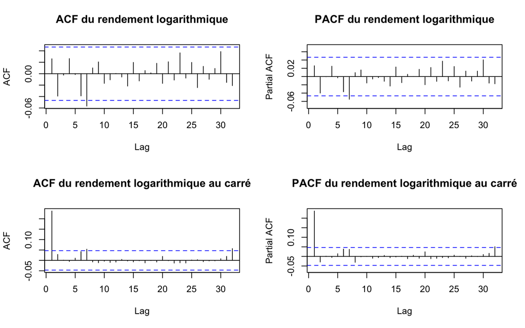

Lorsque nous observons l’ACF et la PACF de notre série `rte` comme convenu une faible autocorrélation à l’ordre 7 dans les rendements, avec une valeur d’autocorrélation d’à peu près 0,055.

Pour la série associée aux carrées des rendements, l’ACF et le PACF montre une forte autocorrélation à l’ordre 1 (de 0.23) mais aussi des faibles autocorrélation aux ordres 7 et 32, avec des valeurs respectives d’à peu près 0.055 et 0.06.

### Réalisation de la statistique de Ljung-Box

#### Hypothèses

$H0 ∶ \rho(k) = 0$ pour k = 1 jusqu’à K $\quad VS \quad H_a : \rho(k) \neq 0$ pour au moins une valeur de k comprise entre 1 et K

#### Cas pratique

##### • Autocorrélations des carrés des rendements rte^2

```
##  [1] 0.000000e+00 0.000000e+00 0.000000e+00 0.000000e+00 0.000000e+00
##  [6] 0.000000e+00 0.000000e+00 0.000000e+00 0.000000e+00 0.000000e+00
## [11] 0.000000e+00 0.000000e+00 0.000000e+00 0.000000e+00 1.110223e-16
## [16] 4.440892e-16 9.992007e-16 2.664535e-15 6.439294e-15 1.199041e-14
## [21] 2.897682e-14 6.006307e-14 1.253442e-13 2.511324e-13 5.527800e-13
```

Toutes les p-values sont inférieures à 0.05 et pour certaines quasiment nulle pour la série `rte^2`. On rejette donc H0 et on conclut à la **présence d’autocorrélation dans les rendements au carré**.

##### • Autocorrélations des rendements rte

```
##  [1] 0.27211467 0.14030388 0.26812117 0.26992492 0.39451529 0.24897486
##  [7] 0.05979320 0.08902201 0.10606701 0.13218978 0.17347010 0.23060635
## [13] 0.29124994 0.30755044 0.33144804 0.38057604 0.44544728 0.51376813
## [19] 0.54073759 0.57146905 0.58385604 0.63031895 0.54315003 0.59543180
## [25] 0.61080472
```

Toutes les p-values sont supérieurs à 0.05 pour `rte`. On accepte donc H0 et on conclut qu’**il n’y a pas d’autocorrélation dans les rendements**.

Nous n’avons donc pas besoin de modéliser cette caractéristique en utilisant un modèle ARMA(p,q).

## Propriété 4 : Clusters de volatilité

### Hypothèses

$H0 ∶ \alpha1 = \alpha2 = ... = \alpha m = 0$ donc homoscédasticité conditionnelle

$VS$

$Ha ∶ \alpha i \neq 0$ avec $i \neq 0$ donc hétéroscédasticité conditionnelle.

*RAPPEL :* Une serie hétéroscédastique dont la variabilité change au cours du temps de façon non évidente.

### Cas pratique

```
##
##  ARCH LM-test; Null hypothesis: no ARCH effects
##
## data:  as.numeric(rte)
## Chi-squared = 99.157, df = 1, p-value < 2.2e-16
```

La p-value est `< 2.2e-16` ce qui est inférieur à 0.05, on rejette donc H0 et donc il y a présence de clusters de volatilité à l’ordre 1 dans `rte`.

```
##
##  ARCH LM-test; Null hypothesis: no ARCH effects
##
## data:  as.numeric(rte)
## Chi-squared = 100.52, df = 2, p-value < 2.2e-16
```

La p-value `< 2.2e-16` ce qui est inférieur à 0.05, on rejette donc H0 et donc il y a présence de clusters de volatilité à l’ordre 2 dans `rte`.

```
##
##  ARCH LM-test; Null hypothesis: no ARCH effects
##
## data:  as.numeric(rte)
## Chi-squared = 107.79, df = 20, p-value = 4.955e-14
```

La p-value est de `4.953e-14` ce qui est inférieur à 0.05, on rejette donc H0. Il y a présence de clusters de volatilité à l’ordre 20 dans `rte`.

```
##
##  ARCH LM-test; Null hypothesis: no ARCH effects
##
## data:  as.numeric(rte)
## Chi-squared = 108.05, df = 30, p-value = 9.548e-11
```

Même conclusion à l’ordre 30. Les p-values sont donc toutes inférieures à 0.05. On rejette alors l’hypothèse nulle, d’homoscédasticité conditionnelle. **Il y a donc des clusters de volatilité dans la série `rte`**.

## Propriété 5 : Queues épaisses conditionnelles

Le but de cette propriété est de modéliser les clusters de volatilité de notre série, pour cela, nous estimons un modèle GARCH(1,1) sur notre série `rte` normalisée.

[output not shown]

[output cut: 46 more lines]

En procédant de cette manière, nous obtenons l’information `FALSE CONVERGENCE`. Pour remédier à cela, nous utilisons la fonction GarchFit :

```
##
## Title:
##  GARCH Modelling
##
## Call:
##  garchFit(formula = rte_centre ~ garch(1, 1), data = rte, include.mean = F,
##     trace = F)
##
## Mean and Variance Equation:
##  data ~ garch(1, 1)
## <environment: 0x11bd7ff00>
##  [data = rte]
##
## Conditional Distribution:
##  norm
##
## Coefficient(s):
##      omega      alpha1       beta1
## 0.00010877  0.02078270  0.77613297
##
## Std. Errors:
##  based on Hessian
##
## Error Analysis:
##         Estimate  Std. Error  t value Pr(>|t|)
## omega  1.088e-04   3.137e-05    3.467 0.000526 ***
## alpha1 2.078e-02   6.149e-03    3.380 0.000726 ***
## beta1  7.761e-01   6.035e-02   12.861  < 2e-16 ***
## ---
## Signif. codes:  0 '***' 0.001 '**' 0.01 '*' 0.05 '.' 0.1 ' ' 1
##
## Log Likelihood:
##  4143.395    normalized:  2.352865
##
## Description:
##  Wed Oct 16 11:42:32 2024 by user:
##
##
## Standardised Residuals Tests:
##                                    Statistic   p-Value
##  Jarque-Bera Test   R    Chi^2  9.967556e+04 0.0000000
##  Shapiro-Wilk Test  R    W      6.651092e-01 0.0000000
##  Ljung-Box Test     R    Q(10)  7.691060e+00 0.6589847
##  Ljung-Box Test     R    Q(15)  9.792420e+00 0.8325901
##  Ljung-Box Test     R    Q(20)  1.117242e+01 0.9416280
##  Ljung-Box Test     R^2  Q(10)  4.462994e+00 0.9240535
##  Ljung-Box Test     R^2  Q(15)  4.879132e+00 0.9931012
##  Ljung-Box Test     R^2  Q(20)  6.270421e+00 0.9984796
##  LM Arch Test       R    TR^2   4.629431e+00 0.9692261
##
## Information Criterion Statistics:
##       AIC       BIC       SIC      HQIC
## -4.702323 -4.692998 -4.702329 -4.698877
```

Nous avons enlevé la constante car sa p-value était supérieur à 0.05.

> Dans le cas où nous effectuerions l’ArchTest directement sur `volat2@residuals` (qui présente de l’autocorrélation) nous rencontrons des effets ARCH qu’il n’est impossible d’éviter. Dans ce cas-là, nous ne pouvons ni conclure ni effectuer l’`anscombe.test`.

Après quelque recherche personnelle, j’ai tout de même pris l’initiative de normalisé les résidus afin de ne plus avoir d’autocorrélation :

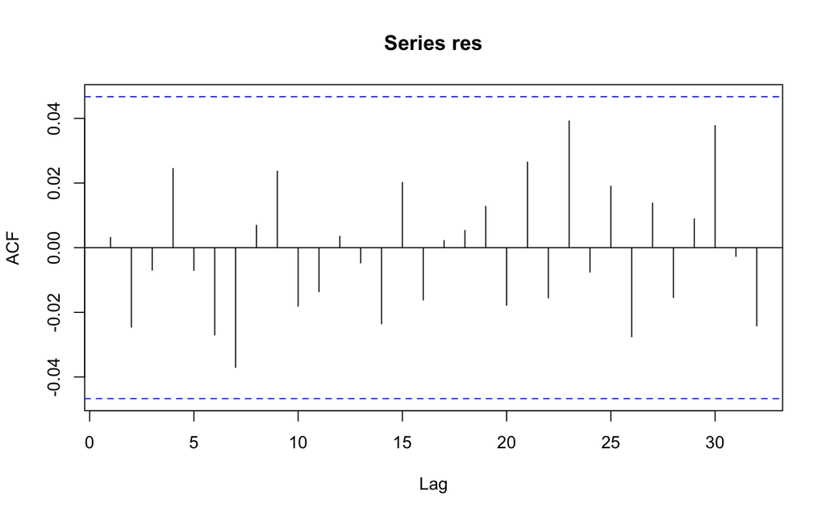

Nous pouvons désormais effectuer les ArchTest :

```r
ArchTest(res, lag=1)
```

```
##
##  ARCH LM-test; Null hypothesis: no ARCH effects
##
## data:  res
## Chi-squared = 2.1107, df = 1, p-value = 0.1463
```

```r
ArchTest(res, lag=20)
```

```
##
##  ARCH LM-test; Null hypothesis: no ARCH effects
##
## data:  res
## Chi-squared = 6.0561, df = 20, p-value = 0.9988
```

```r
ArchTest(res, lag=30)
```

```
##
##  ARCH LM-test; Null hypothesis: no ARCH effects
##
## data:  res
## Chi-squared = 6.9336, df = 30, p-value = 1
```

*NOTE:* Dans le cadre où nous aurions gardé `volat2@residuals` nous n’aurions pas pu enlever les effets ARCH et nous n’aurons pas pu conclure et faire l’étape suivante.

Maintenant, on cherche à voir si les queues de distribution des aléas de notre ARMA-GARCH sont plus épaisses que celles d’une loi normale.

$H0 ∶$ kurtosis $= 3 \quad VS \quad Ha :$ kurtosis $\neq 3$

```
##
##  Anscombe-Glynn kurtosis test
##
## data:  res
## kurt = 39.655, z = 23.540, p-value < 2.2e-16
## alternative hypothesis: kurtosis is not equal to 3
```

## Propriété 6 : Effet de levier

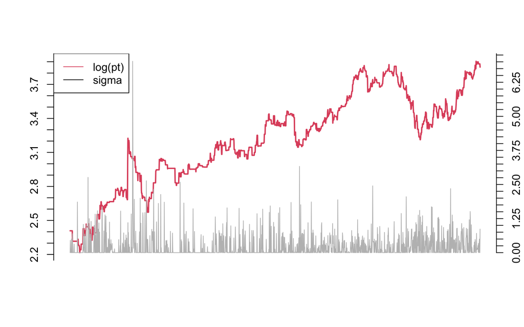

On voit que les périodes de chute de marché sont caractérisées par une augmentation de la volatilité supérieur à celle consécutive à une hausse des cours. Mais pas systématiquement, on en conclut tout de même à la **présence d’effet de levier**.

## Propriété 7 : La saisonnalité

### 7.1 Effet week-end

Les marchés financiers sont affectés par l’accumulation d’information durant les périodes de clôture du week-end ou encore durant les jours fériés ou après les vacances. D’après French et Roll (1986), Baillie et Bollerslev (1989) la variance des rendements augmente à partir du mercredi alors que d’après French et Roll (1986) elle est la plus forte le lundi.

```
##                            Monday      Tuesday    Wednesday   Thursday
## moyenne en %            0.1419401  0.009136317  0.059470246  0.1781682
## écart-type annuel en % 38.1400629 30.612021428 35.831269108 33.4307005
## skewness                1.2885341  0.108426382  0.007177307  0.8343235
## kurtosis               17.3419876  9.373960063  7.624808739 11.9351791
##                             Friday
## moyenne en %            0.01968254
## écart-type annuel en % 46.28398159
## skewness                4.15010853
## kurtosis               57.28542163
```

### 7.2 Effet janvier

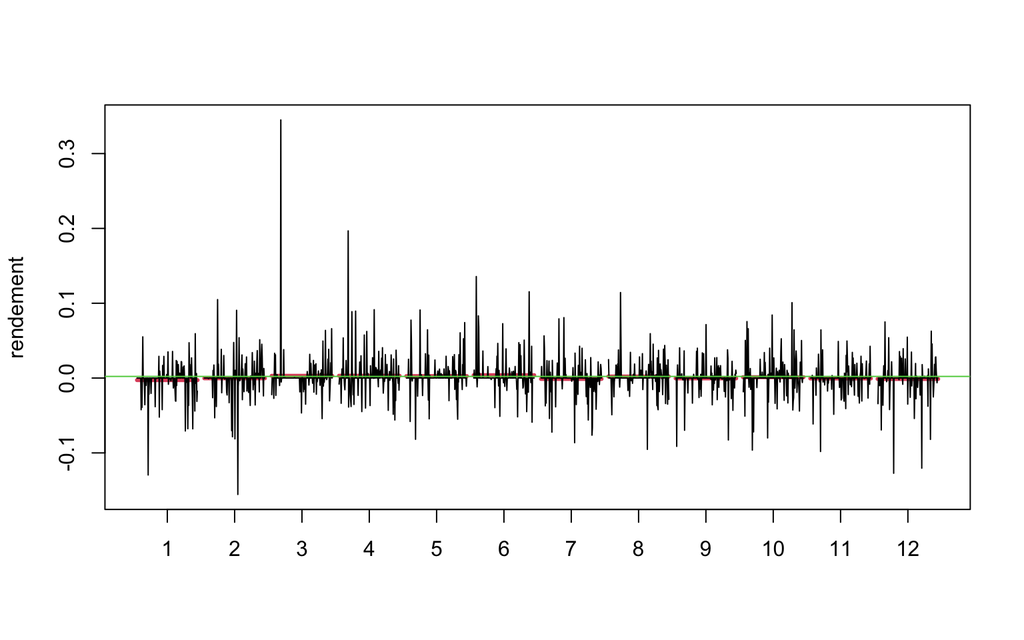

Les moyennes des rendements semblent constantes sur l’année mise à part une légère baisse en janvier, juillet et décembre. **Il ne semble donc pas y avoir d’effet janvier**.

Nous pouvons cependant trouver un écart à la moyenne au mois de mars, on peut donc constater un **effet mars**.

## Propriété 8 : Stationnarité

### Dickey Fuller (DF)

#### • Spécification Trend

Nous allons commencer par la spécification *“trend”* qui consiste à estimer par les MCO :

$$\Delta y_t = (\rho - 1) y_{t-1} + \beta_0 + \beta_1 \text{tendance}_t +
\epsilon_t$$

puis à tester :

$$H_0 : \rho - 1 = 0 \text{ et } \beta_1 = 0 \quad vs \quad H_a : |\rho|
< 1 \text{ et } \beta_1 \neq 0$$

Nous testons d’abord la significativité de $\beta_1$ pour vérifier que la spécification soit la bonne :

$$H_0 : \beta_1 = 0 \quad vs \quad H_a : \beta_1 \neq 0$$

L’hypothèse nulle est rejetée au risque $\alpha$ de 5% si la *p-value* associée à $\beta_1$ est inférieure à $\alpha$.

```
##
## ###############################################
## # Augmented Dickey-Fuller Test Unit Root Test #
## ###############################################
##
## Test regression trend
##
##
## Call:
## lm(formula = z.diff ~ z.lag.1 + 1 + tt)
##
## Residuals:
##      Min       1Q   Median       3Q      Max
## -0.15630 -0.00105 -0.00082 -0.00014  0.34404
##
## Coefficients:
##               Estimate Std. Error t value Pr(>|t|)
## (Intercept)  9.591e-04  1.118e-03   0.858    0.391
## z.lag.1     -9.739e-01  2.385e-02 -40.835   <2e-16 ***
## tt          -1.979e-07  1.099e-06  -0.180    0.857
## ---
## Signif. codes:  0 '***' 0.001 '**' 0.01 '*' 0.05 '.' 0.1 ' ' 1
##
## Residual standard error: 0.02343 on 1757 degrees of freedom
## Multiple R-squared:  0.4869, Adjusted R-squared:  0.4863
## F-statistic: 833.7 on 2 and 1757 DF,  p-value: < 2.2e-16
##
##
## Value of test-statistic is: -40.8347 555.823 833.7345
##
## Critical values for test statistics:
##       1pct  5pct 10pct
## tau3 -3.96 -3.41 -3.12
## phi2  6.09  4.68  4.03
## phi3  8.27  6.25  5.34
```

On voit que $\beta_1$ le coefficient associé à la tendance nommée `tt` dans R n’est pas significative (puisque sa p-value dans la colonne `Pr(>||)` dans R est supérieur à 0.05), on accepte donc H0. Cela implique que le processus qui a généré les données ne pourra pas être TS. On passe au modèle contenant une constante, mais pas de tendance.

#### • Spécification Drift

La spécification *“drift”* consiste à estimer par les MCO :

$$\Delta y_t = (\rho - 1) y_{t-1} + \beta_0 + \epsilon_t$$

puis à tester :

$$H_0 : \rho - 1 = 0 \text{ et } \beta_0 = 0 \quad vs \quad H_a : |\rho|
< 1 \text{ et } \beta_0 \neq 0$$

Nous commençons par tester la significativité de $\beta_0$ pour vérifier que la spécification soit la bonne :

$$H_0 : \beta_0 = 0 \quad vs \quad H_a : \beta_0 \neq 0$$

L’hypothèse nulle est rejetée au risque $\alpha$ de 5% si la *p-value* associée à $\beta_0$ est inférieure à $\alpha$.

```
##
## ###############################################
## # Augmented Dickey-Fuller Test Unit Root Test #
## ###############################################
##
## Test regression drift
##
##
## Call:
## lm(formula = z.diff ~ z.lag.1 + 1)
##
## Residuals:
##      Min       1Q   Median       3Q      Max
## -0.15632 -0.00106 -0.00078 -0.00017  0.34416
##
## Coefficients:
##               Estimate Std. Error t value Pr(>|t|)
## (Intercept)  0.0007848  0.0005586   1.405     0.16
## z.lag.1     -0.9738515  0.0238423 -40.845   <2e-16 ***
## ---
## Signif. codes:  0 '***' 0.001 '**' 0.01 '*' 0.05 '.' 0.1 ' ' 1
##
## Residual standard error: 0.02342 on 1758 degrees of freedom
## Multiple R-squared:  0.4869, Adjusted R-squared:  0.4866
## F-statistic:  1668 on 1 and 1758 DF,  p-value: < 2.2e-16
##
##
## Value of test-statistic is: -40.8455 834.1775
##
## Critical values for test statistics:
##       1pct  5pct 10pct
## tau2 -3.43 -2.86 -2.57
## phi1  6.43  4.59  3.78
```

On voit $\beta_0$ la constante (nommée `Intercept` dans R) n’est pas significative (0.16 > 0.05) donc on accepte H0 et cette régression n’est pas la bonne.

#### • Spécification None

```
##
## ###############################################
## # Augmented Dickey-Fuller Test Unit Root Test #
## ###############################################
##
## Test regression none
##
##
## Call:
## lm(formula = z.diff ~ z.lag.1 - 1)
##
## Residuals:
##      Min       1Q   Median       3Q      Max
## -0.15553 -0.00029  0.00000  0.00064  0.34494
##
## Coefficients:
##         Estimate Std. Error t value Pr(>|t|)
## z.lag.1 -0.97270    0.02383  -40.81   <2e-16 ***
## ---
## Signif. codes:  0 '***' 0.001 '**' 0.01 '*' 0.05 '.' 0.1 ' ' 1
##
## Residual standard error: 0.02343 on 1759 degrees of freedom
## Multiple R-squared:  0.4863, Adjusted R-squared:  0.4861
## F-statistic:  1665 on 1 and 1759 DF,  p-value: < 2.2e-16
##
##
## Value of test-statistic is: -40.81
##
## Critical values for test statistics:
##       1pct  5pct 10pct
## tau1 -2.58 -1.95 -1.62
```

La `t calculé` = -40.81 < -1.95 donc on rejette H0. On en conclut que **le PGD est stationnaire**.

Cette conclusion n’est valide que si les aléas de la régression de Dickey et Fuller ne sont pas auto-corrélés. Vérifions cela maintenant :

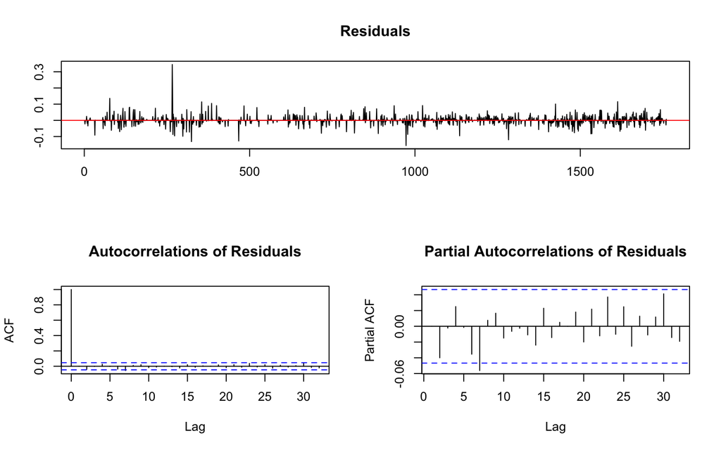

D’après l’ACF toutes les valeurs des coefficients d’autocorrélation semblent se situer dans l’intervalle de confiance mis à part celle à l’ordre 0 et 7. **Il semble donc y avoir de l’autocorrélation**.

Dans la PACF, cela semble se confirmer, car l’ensemble des coefficients d’autocorrélation partiels se situent dans l’intervalle de confiance mis à part à l’ordre 7.

**Nous devons donc effectuer un test de RU dans le cadre de la régression ADF**.

### Dickey Fuller Augmenté (ADF)

Le test ADF correspond à un test DF avec des variables explicatives en plus qui représentent la variable retardée jusqu’à l’ordre P :

$$\Delta y_t = (\rho - 1) y_{t-1} + \sum_{p=1}^{P} \gamma_p \Delta y_{t-p}
+ \epsilon_t$$

La valeur de Pmax est calculée par la formule de Schwert (1989) : $[12 \times (T/100)^0,25]$

```
## Le critère de Schwert est calculé comme étant égal à 24 .
```

#### • MAIC

$$MAIC(p) = \ln(\hat{\sigma}^2_p) + 2 \frac{(\tau_T(p)+p)}{T-Pmax}$$

```
## Augmented DF test
##                                                 ADF test
## t-test statistic:                          -4.054167e+01
## p-value:                                    4.321472e-08
## Max lag of the diff. dependent variable:    0.000000e+00
##
## Call:
## dynlm(formula = formula(model), start = obs.1, end = obs.T)
##
## Residuals:
##      Min       1Q   Median       3Q      Max
## -0.15553 -0.00028  0.00000  0.00066  0.34494
##
## Coefficients:
##         Estimate Std. Error t value Pr(>|t|)
## L(y, 1)   -0.973      0.024  -40.54 4.32e-08 ***
## ---
## Signif. codes:  0 '***' 0.001 '**' 0.01 '*' 0.05 '.' 0.1 ' ' 1
##
## Residual standard error: 0.02355 on 1735 degrees of freedom
## Multiple R-squared:  0.4865, Adjusted R-squared:  0.4862
## F-statistic:    NA on NA and NA DF,  p-value: NA
```

`“Max lag of the diff. dependent variable”` nous indique le nombre de variables explicatives à ajouter pour tenir compte de l’autocorrélation.

Nous avons ici `“Max lag of the diff. dependent variable”` = 0, on doit donc faire le BIC.

#### • BIC

```
## Augmented DF test
##                                                 ADF test
## t-test statistic:                          -4.054167e+01
## p-value:                                    4.321472e-08
## Max lag of the diff. dependent variable:    0.000000e+00
##
## Call:
## dynlm(formula = formula(model), start = obs.1, end = obs.T)
##
## Residuals:
##      Min       1Q   Median       3Q      Max
## -0.15553 -0.00028  0.00000  0.00066  0.34494
##
## Coefficients:
##         Estimate Std. Error t value Pr(>|t|)
## L(y, 1)   -0.973      0.024  -40.54 4.32e-08 ***
## ---
## Signif. codes:  0 '***' 0.001 '**' 0.01 '*' 0.05 '.' 0.1 ' ' 1
##
## Residual standard error: 0.02355 on 1735 degrees of freedom
## Multiple R-squared:  0.4865, Adjusted R-squared:  0.4862
## F-statistic:    NA on NA and NA DF,  p-value: NA
```

*COURS :* Si le MAIC et le BIC vous donnent `pmax = 0`, alors vous allez introduite pmax variables explicatives additionnelles dans la régression puis ôtez un par un les $\gamma$ qui ne sont pas significatifs jusqu’à aboutir à un modèle où le dernier $\gamma$ est significatif sachant qu’on s’accorde à dire que $\gamma$ est significatif si la valeur absolue de sa statistique $t > 1.6$. Vous pouvez ainsi aboutir à un modèle avec `lag=3` car $\gamma_1$ ni $\gamma_2$ ne le sont :

```r
summary(ur.df(rte,type= "none",lags=Schwert))
summary(ur.df(rte,type= "none",lags=Schwert-1))
```

```r
summary(ur.df(rte,type= "none",lags=Schwert-2))
```

```
##
## ###############################################
## # Augmented Dickey-Fuller Test Unit Root Test #
## ###############################################
##
## Test regression none
##
##
## Call:
## lm(formula = z.diff ~ z.lag.1 - 1 + z.diff.lag)
##
## Residuals:
##      Min       1Q   Median       3Q      Max
## -0.15587 -0.00242  0.00009  0.00291  0.34139
##
## Coefficients:
##                Estimate Std. Error t value Pr(>|t|)
## z.lag.1      -1.0191970  0.1209829  -8.424   <2e-16 ***
## z.diff.lag1   0.0480750  0.1182541   0.407    0.684
## z.diff.lag2   0.0104149  0.1155344   0.090    0.928
## z.diff.lag3   0.0129174  0.1125975   0.115    0.909
## z.diff.lag4   0.0363561  0.1096930   0.331    0.740
## z.diff.lag5   0.0353415  0.1065995   0.332    0.740
## z.diff.lag6  -0.0001205  0.1034080  -0.001    0.999
## z.diff.lag7  -0.0534879  0.1000466  -0.535    0.593
## z.diff.lag8  -0.0438052  0.0966531  -0.453    0.650
## z.diff.lag9  -0.0256070  0.0929728  -0.275    0.783
## z.diff.lag10 -0.0394657  0.0892939  -0.442    0.659
## z.diff.lag11 -0.0445353  0.0855208  -0.521    0.603
## z.diff.lag12 -0.0448456  0.0815906  -0.550    0.583
## z.diff.lag13 -0.0535724  0.0774903  -0.691    0.489
## z.diff.lag14 -0.0761009  0.0732790  -1.039    0.299
## z.diff.lag15 -0.0510306  0.0686515  -0.743    0.457
## z.diff.lag16 -0.0619975  0.0635729  -0.975    0.330
## z.diff.lag17 -0.0535323  0.0586264  -0.913    0.361
## z.diff.lag18 -0.0527441  0.0536211  -0.984    0.325
## z.diff.lag19 -0.0330611  0.0480691  -0.688    0.492
## z.diff.lag20 -0.0526982  0.0415137  -1.269    0.204
## z.diff.lag21 -0.0275778  0.0336980  -0.818    0.413
## z.diff.lag22 -0.0390347  0.0241996  -1.613    0.107
## ---
## Signif. codes:  0 '***' 0.001 '**' 0.01 '*' 0.05 '.' 0.1 ' ' 1
##
## Residual standard error: 0.02356 on 1715 degrees of freedom
## Multiple R-squared:  0.4923, Adjusted R-squared:  0.4855
## F-statistic:  72.3 on 23 and 1715 DF,  p-value: < 2.2e-16
##
##
## Value of test-statistic is: -8.4243
##
## Critical values for test statistics:
##       1pct  5pct 10pct
## tau1 -2.58 -1.95 -1.62
```

Avec un lag de 22, le dernier coefficient a comme valeur absolue de sa statistique test supérieur à 1.6, c’est donc significatif. Le dernier coefficient est supérieur à 1.6, c’est donc significatif. De plus, comme la statistique de test de -8.42 est bien plus basse que la valeur critique au seuil de 5 %, nous pouvons rejeter l’hypothèse nulle de racine unitaire (non-stationnarité). Sur la base des résultats du test ADF, il semble que **la série `rte` testée est stationnaire**.

*COURS :* Selon Perron (1989), les tests DF et ADF auront tendance à accepter H0 quand ils sont appliqués à une série stationnaire dont la tendance a subi un changement structurel.

### Zivot et Andrews (ZA)

Ici, nous réalisons la méthode décrite par Perron en 1989 qui consiste à partir de la forme de Schwert puis de diminuer le nombre de $\gamma$ de tel sorte que le dernier ait une statistique t en valeur absolue < 1.6 et l’avant dernier une statistique t en valeur absolue supérieur 1.6 :

$$H_0 : \rho = 1 \quad vs \quad H_a : |\rho| < 1 \$$

```r
summary(ur.za(rte, model="both",lag=24))
summary(ur.za(rte, model="both",lag=23))
summary(ur.za(rte, model="both",lag=22))
summary(ur.za(rte, model="both",lag=21))
summary(ur.za(rte, model="both",lag=20))
summary(ur.za(rte, model="both",lag=19))
summary(ur.za(rte, model="both",lag=18))
summary(ur.za(rte, model="both",lag=17))
summary(ur.za(rte, model="both",lag=16))
summary(ur.za(rte, model="both",lag=15))
summary(ur.za(rte, model="both",lag=14))
summary(ur.za(rte, model="both",lag=13))
summary(ur.za(rte, model="both",lag=12))
summary(ur.za(rte, model="both",lag=11))
summary(ur.za(rte, model="both",lag=10))
summary(ur.za(rte, model="both",lag=9))
summary(ur.za(rte, model="both",lag=8))
summary(ur.za(rte, model="both",lag=7))
summary(ur.za(rte, model="both",lag=6))
summary(ur.za(rte, model="both",lag=5))
summary(ur.za(rte, model="both",lag=4))
summary(ur.za(rte, model="both",lag=3))
```

*NOTE :* Nous ne pouvons pas rigoureusement dans notre cas appliquer la méthode de Perron. Car la condition n’est jamais atteinte. On prendra donc ici le modèle qui s’y rapproche le plus soit `lag = 2` :

```r
summary(ur.za(rte, model="both",lag=2))
```

```
##
## ################################
## # Zivot-Andrews Unit Root Test #
## ################################
##
##
## Call:
## lm(formula = testmat)
##
## Residuals:
##      Min       1Q   Median       3Q      Max
## -0.15609 -0.00225 -0.00022  0.00118  0.33535
##
## Coefficients:
##               Estimate Std. Error t value Pr(>|t|)
## (Intercept) -3.542e-03  2.910e-03  -1.217  0.22380
## y.l1        -2.922e-02  4.138e-02  -0.706  0.48015
## trend        4.745e-05  1.845e-05   2.571  0.01022 *
## y.dl1        5.083e-02  3.340e-02   1.522  0.12823
## y.dl2        5.615e-03  2.389e-02   0.235  0.81423
## du          -9.776e-03  3.114e-03  -3.140  0.00172 **
## dt          -4.629e-05  1.850e-05  -2.502  0.01246 *
## ---
## Signif. codes:  0 '***' 0.001 '**' 0.01 '*' 0.05 '.' 0.1 ' ' 1
##
## Residual standard error: 0.02338 on 1751 degrees of freedom
##   (3 observations deleted due to missingness)
## Multiple R-squared:  0.007909,   Adjusted R-squared:  0.004509
## F-statistic: 2.326 on 6 and 1751 DF,  p-value: 0.03055
##
##
## Teststatistic: -24.8727
## Critical values: 0.01= -5.57 0.05= -5.08 0.1= -4.82
##
## Potential break point at position: 272
```

On voit que :

La statistique de test est $-24.8727 < −5.08$ la valeur critique à 5 %. On rejette donc H0.

**Cela pourrait nous amener à penser que le PGD est TS avec un changement structurel**. Cependant, cette conclusion ne peut pas être tirée de manière définitive. Il est aussi envisageable que le PGD soit DS avec un changement structurel.

La date de rupture est la 272e observation qui correspond à la date :

```
## [1] "2014-01-31"
```

Nous pouvons constater la date de rupture sur le graphique ci-dessous :

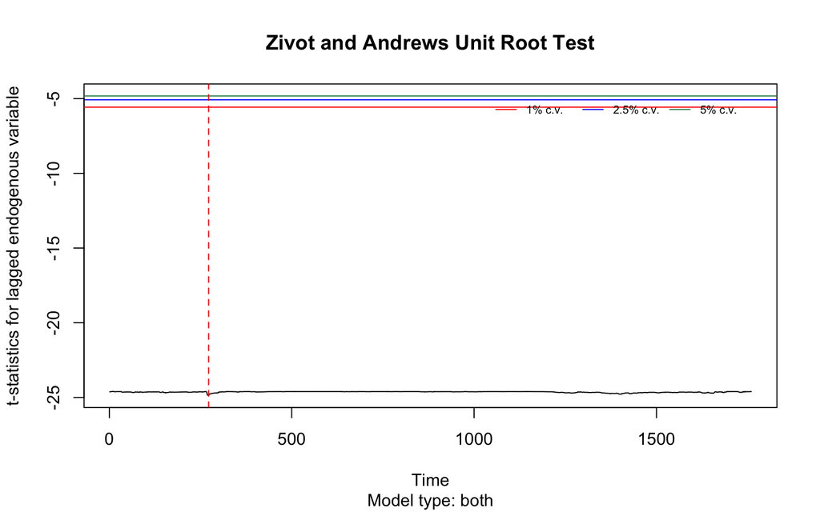

> En janvier 2014, Square Enix avait commencé à se redresser après plusieurs années difficiles dues à des titres décevants et des pertes financières. En effet, en 2013, la société a publié plusieurs jeux à succès, dont “Final Fantasy XIV: A Realm Reborn”, qui a été un succès critique et commercial après l’échec de la version initial en 2010. Ce relancement a probablement soutenu les performances financières de la société, stimulant ainsi la confiance des investisseurs. L’impact de ce redressement a pu se faire sentir au début de 2014, expliquant cette date de rupture.

### Lee et Strazicich (LS)

Le test de Lee et Strazicich est une généralisation du test de racine unitaire de Schmidt et Phillips (SP). Ils ont généralisé le test SP en employant la classification des changements structurels de Perron (1989) ”crash” et ”both” sachant qu’ils les appellent respectivement ”crash”et ”break” et en introduisant 2 dates de rupture endogènes. Le mod`ele est le suivant :

$$y_t = \delta' Z_t + e_t
e_t = \beta e_{t-1} + \varepsilon_t$$

avec $\varepsilon \sim \mathcal{N}(0,\sigma^2)$ et $Z$ la matrice des variables exogènes.

Soit $T_{B1}$ la date du premier changement structurel et $T_{B2}$ la date du second.

- ”crash” : $Z_t = [\iota, tendance, DU_{1t}, DU_{2t}]'$ avec $DU_{jt} = 1$ si $t≥T_{Bj} + 1$ pour $j=1,2$ et $0$ sinon
- ”break” : $Z_t = [\iota, tendance, DU_{1t}, DU_{2t}, DT_{1t} , DT_{2t}]'$ avec $DT_{jt} = t- T_{Bj}$ si $t≥T_{Bj} + 1$ pour $j=1,2$ et $0$ sinon

VS

VS

Notons que dans tous les cas, le PGD comprend des changements structurels sous H0 et sous Ha.

Le test LS peut s’effectuer avec ou sans boostrap. Dans notre cas, nous n’utiliserons pas boostrap car ce dernier est employé lorsque nous avons un faible nombre d’observation. Ce qui n’est pas le cas pour notre sére `rte` (nombre de jour supérieur à 100).

```
## [1] -8.208037
## [1] "First possible structural break at position: 1525"
## [1] "The location of the first break - lambda_1: 0.9 , with the number of total observations: 1761"
## Critical values - Crash model:
##          1%     5%    10%
## [1,] -4.239 -3.566 -3.211
## [1] "Number of lags determined by general-to-specific lag selection: 22"
## Runtime:
## Time difference of 0.295996 mins
```

`First possible structural break at position: 1525`

Cette position correspond à la date :

```
## [1] "2019-01-24"
```

> Cette date de rupture peut avoir un lien avec un ralentissement temporaire après une période de grande anticipation. En effet, en janvier 2019, il y avait une grande attente autour de la sortie du jeu “Kingdom Hearts III”, qui est finalement sorti le 25 janvier 2019. Souvent, lorsque la sortie d’un jeu très attendu approche, les investisseurs peuvent être prudents, ce qui peut provoquer une baisse des actions en raison des incertitudes sur les critiques et les ventes réelles. Après le pic d’attente, certains investisseurs peuvent avoir décidé de prendre leurs bénéfices, entraînant une chute temporaire de l’action avant que les performances réelles ne soient connues.

La valeur de la statistique du test est -8.208032 ce qui est inférieur à la valeur critique -3.566. On rejette alors H0 ce qui nous permet de conclure que le PGD qui a généré la série `rte` et donc il n’y a pas de racine unitaire.

De plus, le PGD ne peut pas être TS puisque nous avons vu qu’il n’y a pas de tendance. **La conclusion est que le PGD qui a généré notre série est stationnaire avec une date de rupture en janvier 2019**.

# Étude des 8 caractéristiques la série rtt

Voici le chronogramme de la série `rtt` :

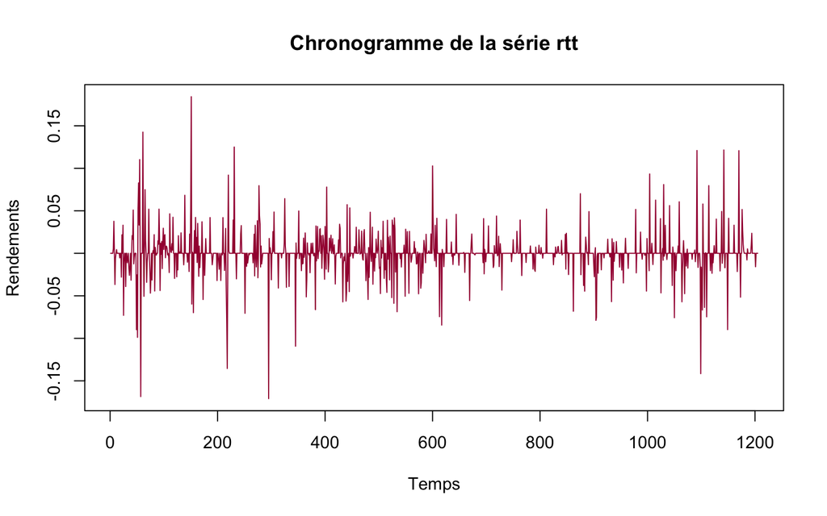

La série `rtt` n’a visuellement pas l’air d’avoir de tendance, elle fluctue autour de 0. De plus, la variance ne semble pas non plus varier au cours du temps

## Propriété 1 : Asymétrie perte / gain

### Hypothèses

$H_0 : E\left[\left(\frac{X - E(X)}{\sigma_X}\right)^3\right] = 0 \quad VS \quad H_a : E\left[\left(\frac{X - E(X)}{\sigma_X}\right)^3\right] \neq 0$

### Cas pratique

```
##
##  D'Agostino skewness test
##
## data:  rtt
## skew = 0.024423, z = 0.348186, p-value = 0.7277
## alternative hypothesis: data have a skewness
```

Le coefficient du skewness n’est pas significatif puisque la p-value étant supérieur 0.05 on accepte donc H0. La skewness est statistiquement nulle, **la distribution est symétrique**.

## Propriété 2 : Queues de distribution épaisses

### Hypothèses

$H_0 : E\left[\left(\frac{X - E(X)}{\sigma_X}\right)^4\right] = 3 \quad VS \quad H_a : E\left[\left(\frac{X - E(X)}{\sigma_X}\right)^4\right] \neq 3$

### Cas pratique

```
##
##  Anscombe-Glynn kurtosis test
##
## data:  rtt
## kurt = 16.235, z = 16.046, p-value < 2.2e-16
## alternative hypothesis: kurtosis is not equal to 3
```

La p-value du test d’Anscombe étant `< 2.2e-16` est inférieur à 0.05 on rejette H0, ce qui indique que le kurtosis est significatif. Celui-ci vaut `16` > 3 la distribution est donc **leptokurtique**. Ainsi, les queues de distribution sont plus épaisses que celles d’une loi normale centrée réduite.

## Propriété 3 : Autocorrélations des carrés des rendements fortes et faibles pour les rendements

### Réalisation de l’ACF et de la PACF

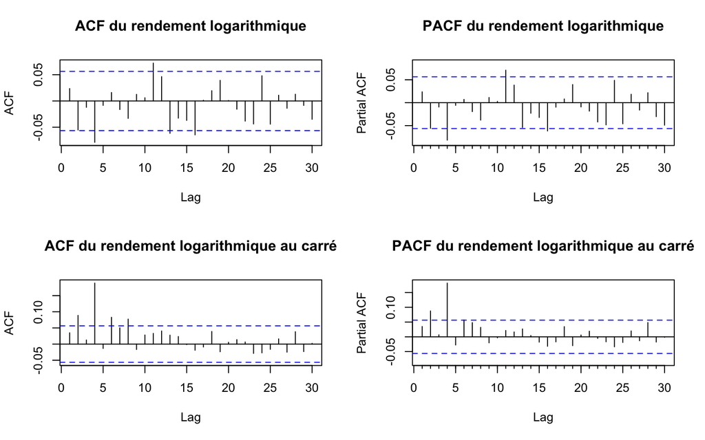

### Réalisation de la statistique de Ljung-Box

#### Hypothèses

$H0 ∶ \rho(k) = 0$ pour k = 1 jusqu’à K $\quad VS \quad H_a : \rho(k) \neq 0$ pour au moins une valeur de k comprise entre 1 et K

#### Cas pratique

##### • Autocorrélations des carrés des rendements $rtt^2$

```
##  [1] 2.251423e-01 4.080430e-03 1.070446e-02 4.339640e-11 1.562628e-10
##  [6] 1.127276e-11 9.385603e-12 1.089906e-12 2.960188e-12 5.737744e-12
## [11] 9.009904e-12 1.024947e-11 1.808276e-11 3.462319e-11 8.510448e-11
## [16] 1.682038e-10 3.721917e-10 3.919319e-10 6.534834e-10 1.380923e-09
## [21] 2.637172e-09 5.277955e-09 7.164934e-09 9.993769e-09 1.711994e-08
```

Toutes les p-values sont inférieures à 0.05 pour `rtt^2` à part à l’ordre 1. On rejette donc H0 et on conclut à la **présence d’autocorrélation dans les rendements au carré**.

##### • Autocorrélations des rendements rtt

```
##  [1] 0.410169938 0.112326608 0.207942501 0.016869596 0.032766835 0.052318500
##  [7] 0.077423585 0.078500689 0.111371016 0.156937599 0.036355095 0.024923258
## [13] 0.009136350 0.009592500 0.008935130 0.002851463 0.004518923 0.006054506
## [19] 0.005261552 0.007886371 0.010621298 0.009393352 0.007143506 0.004768310
## [25] 0.003594292
```

Les p-values aux ordres 4, 5 et toutes celles partir de 11 sont inférieurs à 0.05 pour `rtt`. On rejette donc H0 et on conclut qu’il y a **présence d’autocorrélation**.

Pour modéliser cette caractéristique, nous utiliserons un modèle ARMA(p,q) dont la mise en œuvre contient 3 étapes.

#### • Étape 1 : Détermination de p et p du ARMA(p,q) via l’eacf

```
## AR/MA
##   0 1 2 3 4 5 6 7 8 9 10 11 12 13
## 0 o o o x o o o o o o x  o  x  o
## 1 x x o x o o o o o o o  o  x  o
## 2 x x o x o o o o o o o  o  x  o
## 3 x x x x o o o o o o o  o  x  o
## 4 x x x x o o o o o o o  o  o  o
## 5 x o x x x o o o o o o  o  o  o
## 6 x x x x o o o o o o o  o  o  o
## 7 x x x x x x x o o o o  o  o  o
```

On trouve p = 4 et q = 4.

#### • Étape 2 : Estimation du modèle ARMA(p,q) avec les valeurs trouvées via l’eacf

##### Estimation du modèle ARMA(4,4)

```
##
## z test of coefficients:
##
##              Estimate  Std. Error z value Pr(>|z|)
## ar1        0.39206857  0.25535948  1.5354  0.12470
## ar2       -0.46900204  0.32035285 -1.4640  0.14319
## ar3       -0.00073337  0.24705433 -0.0030  0.99763
## ar4        0.51412207  0.32405516  1.5865  0.11262
## ma1       -0.37301450  0.23858570 -1.5634  0.11795
## ma2        0.40964622  0.29979323  1.3664  0.17180
## ma3        0.03278146  0.23545799  0.1392  0.88927
## ma4       -0.61227177  0.30828301 -1.9861  0.04703 *
## intercept -0.00016740  0.00056460 -0.2965  0.76685
## ---
## Signif. codes:  0 '***' 0.001 '**' 0.01 '*' 0.05 '.' 0.1 ' ' 1
```

```
##
## z test of coefficients:
##
##              Estimate  Std. Error z value  Pr(>|z|)
## ar1        0.39832154  0.07465481  5.3355 9.528e-08 ***
## ar2       -0.49957389  0.25652217 -1.9475   0.05148 .
## ar4        0.49381517  0.26990090  1.8296   0.06731 .
## ma1       -0.40355558  0.06440345 -6.2661 3.703e-10 ***
## ma2        0.46089383  0.23919824  1.9268   0.05400 .
## ma4       -0.57724346  0.25344858 -2.2776   0.02275 *
## intercept -0.00015728  0.00054969 -0.2861   0.77478
## ---
## Signif. codes:  0 '***' 0.001 '**' 0.01 '*' 0.05 '.' 0.1 ' ' 1
```

Tous les coefficients ne sont pas significatifs. On enlève l’`intercept` :

```
##
## z test of coefficients:
##
##      Estimate Std. Error z value  Pr(>|z|)
## ar1  0.392089   0.071518  5.4824 4.197e-08 ***
## ar2 -0.520932   0.245810 -2.1192   0.03407 *
## ar4  0.471301   0.258538  1.8229   0.06831 .
## ma1 -0.398030   0.062179 -6.4013 1.540e-10 ***
## ma2  0.481004   0.231260  2.0799   0.03753 *
## ma4 -0.555762   0.244711 -2.2711   0.02314 *
## ---
## Signif. codes:  0 '***' 0.001 '**' 0.01 '*' 0.05 '.' 0.1 ' ' 1
```

Seulement `ar4` n’est pas significatif, on l’enlève :

```
##
## z test of coefficients:
##
##      Estimate Std. Error z value Pr(>|z|)
## ar1  0.161936   0.646347  0.2505 0.802170
## ar2 -0.357917   1.109628 -0.3226 0.747031
## ma1 -0.140932   0.670754 -0.2101 0.833582
## ma2  0.296491   1.110881  0.2669 0.789548
## ma4 -0.099448   0.036485 -2.7257 0.006416 **
## ---
## Signif. codes:  0 '***' 0.001 '**' 0.01 '*' 0.05 '.' 0.1 ' ' 1
```

Il ne reste plus que `ma4` qui à une p-value inférieur à 0.05. On enlève donc le coefficient donc la pvalue est la plus élevée, soit ici `ma1` :

[output not shown]

En procédant toujours de la même manière, c’est-à-dire en enlevant un à un le coefficient dont la p-value est la plus élevée et supérieur à 0.05, on obtient :

```r
reg1<-Arima(rtt, order=c(4,0,4),include.mean=F,fixed=c(0,NA,0,0,NA,NA,0,NA))
reg1<-Arima(rtt, order=c(4,0,4),include.mean=F,fixed=c(NA,NA,0,0,0,NA,0,NA))
reg1<-Arima(rtt, order=c(4,0,4),include.mean=F,fixed=c(NA,NA,0,0,0,0,0,NA))
```

```r
reg1<-Arima(rtt, order=c(4,0,4),include.mean=F,fixed=c(0,NA,0,0,0,0,0,NA))
coeftest(reg1)
```

```
##
## z test of coefficients:
##
##      Estimate Std. Error z value Pr(>|z|)
## ar2 -0.059231   0.028770 -2.0588 0.039514 *
## ma4 -0.086625   0.029379 -2.9485 0.003193 **
## ---
## Signif. codes:  0 '***' 0.001 '**' 0.01 '*' 0.05 '.' 0.1 ' ' 1
```

Le modèle est correct, car tous les coefficients sont significatifs. On détermine maintenant sa valeur de BIC :

```
## [1] -5524.754
```

Afin d’être sûr que ce modèle est le meilleur nous avons tester d’autres modèles :

##### Estimation du modèle ARMA(3,3)

```r
reg2<-Arima(rtt, order=c(3,0,3), fixed=c(NA,NA,NA,NA,NA,NA,NA))
reg2<-Arima(rtt, order=c(3,0,3), fixed=c(NA,0,NA,NA,NA,NA,NA))
reg2<-Arima(rtt, order=c(3,0,3),include.mean=F, fixed=c(NA,0,NA,NA,NA,NA))
```

```r
reg2<-Arima(rtt, order=c(3,0,3),include.mean=F, fixed=c(NA,0,NA,NA,NA,NA))
coeftest(reg2)
```

```
##
## z test of coefficients:
##
##      Estimate Std. Error  z value  Pr(>|z|)
## ar1  0.296069   0.016439  18.0102 < 2.2e-16 ***
## ar3 -0.841153   0.018004 -46.7209 < 2.2e-16 ***
## ma1 -0.281182   0.019155 -14.6790 < 2.2e-16 ***
## ma2 -0.044075   0.015936  -2.7658  0.005678 **
## ma3  0.872531   0.018861  46.2605 < 2.2e-16 ***
## ---
## Signif. codes:  0 '***' 0.001 '**' 0.01 '*' 0.05 '.' 0.1 ' ' 1
```

Le modèle est correct, car tous les coefficients sont significatifs. On détermine maintenant sa valeur de BIC :

```
## [1] -5504.136
```

Le BIC associé à l’ARMA(3,3) est supérieur à celui associé à l’ARMA(4,4) on garde donc notre premier modèle pour l’instant.

##### Estimation du modèle ARMA(1,1)

```r
reg3 = Arima(rtt, order=c(1,0,1))
```

```r
reg3 = Arima(rtt, order=c(1,0,1),include.mean=F)
coeftest(reg3)
```

```
##
## z test of coefficients:
##
##     Estimate Std. Error z value  Pr(>|z|)
## ar1 -0.75475    0.14524 -5.1966 2.030e-07 ***
## ma1  0.79653    0.13349  5.9671 2.415e-09 ***
## ---
## Signif. codes:  0 '***' 0.001 '**' 0.01 '*' 0.05 '.' 0.1 ' ' 1
```

Le modèle est correct, car tous les coefficients sont significatifs. On détermine maintenant sa valeur de BIC :

```
## [1] -5517.399
```

Le BIC associé à l’ARMA(1,1) est supérieur à celui associé à l’ARMA(4,4) on garde donc notre premier modèle pour l’instant.

##### Estimation du modèle MA(13)

```r
reg4<-Arima(rtt, order=c(0,0,13), fixed=c(NA,NA,NA,NA,NA,NA,NA,NA,NA,NA,NA,NA,NA,NA))
reg4<-Arima(rtt, order=c(0,0,13), fixed=c(NA,NA,NA,NA,0,NA,NA,NA,NA,0,NA,NA,NA,NA))
reg4<-Arima(rtt, order=c(0,0,13), fixed=c(NA,NA,0,NA,0,NA,NA,NA,0,0,NA,NA,NA,NA))
reg4<-Arima(rtt, order=c(0,0,13),include.mean=F,fixed=c(NA,NA,0,NA,0,NA,0,NA,0,0,NA,NA,NA))
reg4<-Arima(rtt, order=c(0,0,13),include.mean=F,fixed=c(0,NA,0,NA,0,NA,0,NA,0,0,NA,NA,NA))
reg4<-Arima(rtt, order=c(0,0,13),include.mean=F,fixed=c(0,NA,0,NA,0,NA,0,NA,0,0,NA,0,NA))
```

```r
reg4<-Arima(rtt, order=c(0,0,13),include.mean=F,fixed=c(0,NA,0,NA,0,0,0,0,0,0,NA,0,NA))
coeftest(reg4)
```

```
##
## z test of coefficients:
##
##       Estimate Std. Error z value Pr(>|z|)
## ma2  -0.058485   0.028895 -2.0240 0.042966 *
## ma4  -0.077385   0.029823 -2.5948 0.009465 **
## ma11  0.077665   0.030048  2.5847 0.009747 **
## ma13 -0.074679   0.029364 -2.5433 0.010982 *
## ---
## Signif. codes:  0 '***' 0.001 '**' 0.01 '*' 0.05 '.' 0.1 ' ' 1
```

Le modèle est correct, car tous les coefficients sont significatifs. On détermine maintenant sa valeur de BIC :

```
## [1] -5521.554
```

Le BIC associé à l’MA(13) est supérieur à celui associé à l’ARMA(4,4) on garde donc notre premier modèle.

#### • Étape 3 : Les aléas du modèle ont-ils une espérance nulle et sont-ils non-autocorrélés ?

##### (a) Test d’espérance nulle des aléas du modèle MA sans la constante

$H0 ∶ \mathbb{E}[\varepsilon] = 0 \quad VS \quad Ha ∶ \mathbb{E}[\varepsilon] \neq 0$

```
##
##  One Sample t-test
##
## data:  residu
## t = -0.2756, df = 1204, p-value = 0.7829
## alternative hypothesis: true mean is not equal to 0
## 95 percent confidence interval:
##  -0.001555146  0.001172051
## sample estimates:
##     mean of x
## -0.0001915473
```

La p-value $= 0.78 > 0.05$ donc on accepte H0. On conclut donc que l’espérance des aléas est nulle et on passe au test d’absence d’autocorrélation.

##### (b) Test d’absence d’autocorrélation dans les aléas du modèle ARMA

$H0$ : Absence d’autocorrélation jusqu’à l’ordre K $\quad VS \quad Ha$ : Présence d’autocorrélation

```
##  [1] 0.4742429 0.7738054 0.8890306 0.9593761 0.9847605 0.9846343 0.9916628
##  [8] 0.9603423 0.9782310 0.9894104 0.9948860 0.9747858 0.9852457 0.9774979
## [15] 0.9587143 0.7646733 0.8170635 0.8547036 0.8069271 0.8502889
```

Les p-values sont toutes supérieures à 0.05 donc on accepte H0 et on conclut qu’il n’y a pas d’autocorrélation dans les aléas jusqu’à l’ordre 20.

## Propriété 4 : Clusters de volatilité

### Hypothèses

$H0 ∶ \alpha1 = \alpha2 = ... = \alpha m = 0$ donc homoscédasticité conditionnelle

$VS$

$Ha ∶ \alpha i \neq 0$ avec $i \neq 0$ donc hétéroscédasticité conditionnelle.

### Cas pratique

```
##
##  ARCH LM-test; Null hypothesis: no ARCH effects
##
## data:  as.numeric(rtt)
## Chi-squared = 1.4666, df = 1, p-value = 0.2259
```

```
##
##  ARCH LM-test; Null hypothesis: no ARCH effects
##
## data:  as.numeric(rtt)
## Chi-squared = 10.701, df = 2, p-value = 0.004746
```

```
##
##  ARCH LM-test; Null hypothesis: no ARCH effects
##
## data:  as.numeric(rtt)
## Chi-squared = 64.032, df = 20, p-value = 1.663e-06
```

```
##
##  ARCH LM-test; Null hypothesis: no ARCH effects
##
## data:  as.numeric(rtt)
## Chi-squared = 69.718, df = 30, p-value = 5.295e-05
```

Les p-values sont quasi toutes inférieures à 0.05. On rejette donc H0. **Il y a donc des clusters de volatilité dans la série `rtt`**.

## Propriété 5 : Queues épaisses conditionnelles

[output not shown]

```
##
## Call:
## garch(x = residuv_rtt, order = c(1, 1))
##
## Model:
## GARCH(1,1)
##
## Residuals:
##       Min        1Q    Median        3Q       Max
## -8.356588 -0.136087  0.004485  0.152497  7.501898
##
## Coefficient(s):
##     Estimate  Std. Error  t value Pr(>|t|)
## a0  0.124319    0.016617    7.481 7.35e-14 ***
## a1  0.060215    0.005946   10.127  < 2e-16 ***
## b1  0.814875    0.021160   38.509  < 2e-16 ***
## ---
## Signif. codes:  0 '***' 0.001 '**' 0.01 '*' 0.05 '.' 0.1 ' ' 1
##
## Diagnostic Tests:
##  Jarque Bera Test
##
## data:  Residuals
## X-squared = 9237.9, df = 2, p-value < 2.2e-16
##
##
##  Box-Ljung test
##
## data:  Squared.Residuals
## X-squared = 0.004159, df = 1, p-value = 0.9486
```

En procédant de cette manière, nous obtenons l’information `FALSE CONVERGENCE`. Pour remédier à cela, nous utilisons la fonction GarchFit :

```
##
## Title:
##  GARCH Modelling
##
## Call:
##  garchFit(formula = residuv_rtt ~ garch(1, 1), data = rtt, include.mean = F,
##     trace = F)
##
## Mean and Variance Equation:
##  data ~ garch(1, 1)
## <environment: 0x11cec90e8>
##  [data = rtt]
##
## Conditional Distribution:
##  norm
##
## Coefficient(s):
##      omega      alpha1       beta1
## 6.7058e-05  5.9281e-02  8.2607e-01
##
## Std. Errors:
##  based on Hessian
##
## Error Analysis:
##         Estimate  Std. Error  t value Pr(>|t|)
## omega  6.706e-05   2.373e-05    2.826  0.00471 **
## alpha1 5.928e-02   1.502e-02    3.946 7.96e-05 ***
## beta1  8.261e-01   5.193e-02   15.906  < 2e-16 ***
## ---
## Signif. codes:  0 '***' 0.001 '**' 0.01 '*' 0.05 '.' 0.1 ' ' 1
##
## Log Likelihood:
##  2816.784    normalized:  2.33758
##
## Description:
##  Wed Oct 16 11:45:14 2024 by user:
##
##
## Standardised Residuals Tests:
##                                    Statistic   p-Value
##  Jarque-Bera Test   R    Chi^2  9342.1639120 0.0000000
##  Shapiro-Wilk Test  R    W         0.7019154 0.0000000
##  Ljung-Box Test     R    Q(10)     6.0740021 0.8090080
##  Ljung-Box Test     R    Q(15)    17.8635016 0.2699097
##  Ljung-Box Test     R    Q(20)    21.8623480 0.3480265
##  Ljung-Box Test     R^2  Q(10)     5.4686612 0.8577570
##  Ljung-Box Test     R^2  Q(15)     6.5346781 0.9693011
##  Ljung-Box Test     R^2  Q(20)    11.4957992 0.9323384
##  LM Arch Test       R    TR^2      5.8241723 0.9246845
##
## Information Criterion Statistics:
##       AIC       BIC       SIC      HQIC
## -4.670182 -4.657499 -4.670194 -4.665405
```

```r
ArchTest(volat2@residuals,lag=1)
```

```
##
##  ARCH LM-test; Null hypothesis: no ARCH effects
##
## data:  volat2@residuals
## Chi-squared = 1.4666, df = 1, p-value = 0.2259
```

```r
ArchTest(volat2@residuals,lag=2)
```

```
##
##  ARCH LM-test; Null hypothesis: no ARCH effects
##
## data:  volat2@residuals
## Chi-squared = 10.701, df = 2, p-value = 0.004746
```

```r
ArchTest(volat2@residuals,lag=20)
```

```
##
##  ARCH LM-test; Null hypothesis: no ARCH effects
##
## data:  volat2@residuals
## Chi-squared = 64.032, df = 20, p-value = 1.663e-06
```

Maintenant, on cherche à voir si les queues de distribution des aléas de notre ARMA-GARCH sont plus épaisses que celles d’une loi normale.

$H0 ∶$ kurtosis $= 3 \quad VS \quad Ha :$ kurtosis $\neq 3$

```
##
##  Anscombe-Glynn kurtosis test
##
## data:  volat$res
## kurt = 16.570, z = 16.139, p-value < 2.2e-16
## alternative hypothesis: kurtosis is not equal to 3
```

On trouve une p-value < 2.2e-16 donc on rejette H0. De plus, le kurtosis est supérieur à 3. Ainsi, les queues de distribution des aléas de notre ARMA-GARCH sont plus épaisses que celles d’une loi normale.

## Propriété 6 : Effet de levier

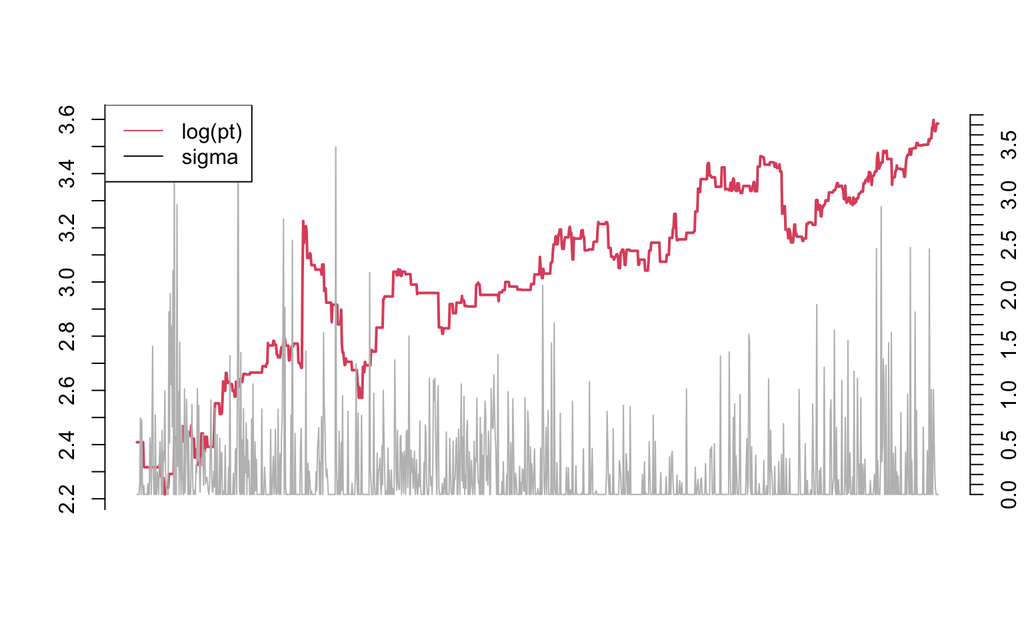

On voit que les périodes de chute de marché sont caractérisées par une augmentation de la volatilité supérieur à celle consécutive à une hausse des cours. On en conclut tout de même à la **présence d’effet de levier**.

## Propriété 7 : La saisonnalité

### 7.1 Effet week-end

Les marchés financiers sont affectés par l’accumulation d’information durant les périodes de clôture du week-end ou encore durant les jours fériés ou après les vacances. D’après French et Roll (1986), Baillie et Bollerslev (1989) la variance des rendements augmente à partir du mercredi alors que d’après French et Roll (1986) elle est la plus forte le lundi.

```
##                            Monday    Tuesday   Wednesday   Thursday      Friday
## moyenne en %           -0.1207257 -0.0680825 -0.07792992  0.1646728  0.01484844
## écart-type annuel en % 38.1946676 41.0560449 31.70533154 45.9232338 35.08432526
## skewness               -0.1876039 -0.8663245 -0.65726369  0.8094279  0.34486163
## kurtosis               12.3573061 14.1920181  4.88498441 14.1945303  7.00658459
```

French et Roll (1986) observent que la variance des rendements est la plus forte le lundi. Cela correspond partiellement à notre tableau, où l’écart-type du lundi est effectivement élevé (38,19 %), bien que ce ne soit pas le plus élevé comparé à d’autres jours (comme le jeudi avec 45,92 %). Cette variance élevée pourrait s’expliquer par l’accumulation d’informations durant le week-end, qui se répercute sur les prix des actifs au début de la semaine, créant une plus grande incertitude et volatilité.

Baillie et Bollerslev (1989) soutiennent que la variance augmente à partir du mercredi. Dans nos données, on observe que l’écart-type du mercredi (31,71 %) est effectivement plus faible que les autres jours, mais une forte hausse de la volatilité se manifeste à partir du jeudi (45,92 %), ce qui pourrait être lié à l’effet d’accumulation d’information au milieu de la semaine, entraînant une instabilité accrue.

### 7.2 Effet janvier

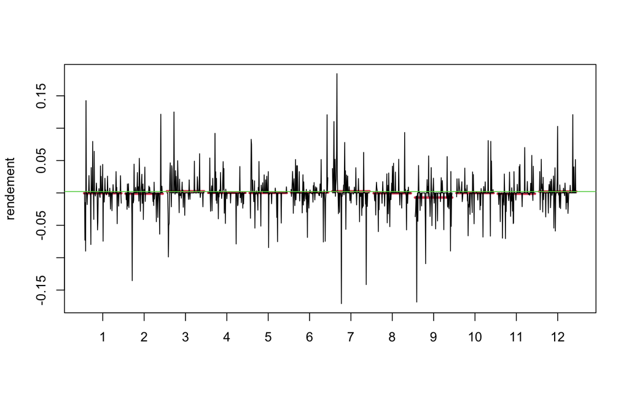

Les moyennes des rendements semblent constantes sur l’année mise à part une légère baisse en février et novembre Il ne semble donc pas y avoir d’effet janvier.

Nous pouvons cependant trouver un écart à la moyenne au mois de septembre où l’écart à la moyenne est élevé (négativement), on peut donc constater un **effet septembre**.

## Propriété 8 : Stationnarité

Un processus stochastique {Xt} est stationnaire au second ordre si :

- $\mathbb{E}[X_t] = \mu$, une constante
- $Var(X_t) < \inf$
- $autocov(X_t,X_{t−s}) = \mathbb{E}[(X_t − \mu)(X_{t−s} − \mu)]= \gamma_s$ qui ne dépend que de s.

Un Bruit Blanc (BB) est une séquence de variables aléatoires iid de moyenne nulle, de variance constante et non autocorrélées. Simulation d’un BB gaussien de moyenne nulle et d’écart-type 1 = tirage aléatoire dans une normale centrée résuite

### Dickey Fuller (DF)

#### • Spécification Trend

Nous allons commencer par la spécification *“trend”* qui consiste à estimer par les MCO :

$$\Delta y_t = (\rho - 1) y_{t-1} + \beta_0 + \beta_1 \text{tendance}_t +
\epsilon_t$$

puis à tester :

$$H_0 : \rho - 1 = 0 \text{ et } \beta_1 = 0 \quad vs \quad H_a : |\rho|
< 1 \text{ et } \beta_1 \neq 0$$

Nous testons d’abord la significativité de $\beta_1$ pour vérifier que la spécification soit la bonne :

$$H_0 : \beta_1 = 0 \quad vs \quad H_a : \beta_1 \neq 0$$

L’hypothèse nulle est rejetée au risque $\alpha$ de 5% si la *p-value* associée à $\beta_1$ est inférieure à $\alpha$.

```
##
## ###############################################
## # Augmented Dickey-Fuller Test Unit Root Test #
## ###############################################
##
## Test regression trend
##
##
## Call:
## lm(formula = z.diff ~ z.lag.1 + 1 + tt)
##
## Residuals:
##       Min        1Q    Median        3Q       Max
## -0.170915 -0.000500  0.000203  0.000644  0.183001
##
## Coefficients:
##               Estimate Std. Error t value Pr(>|t|)
## (Intercept)  7.005e-05  1.406e-03   0.050     0.96
## z.lag.1     -9.763e-01  2.885e-02 -33.845   <2e-16 ***
## tt          -3.831e-07  2.022e-06  -0.189     0.85
## ---
## Signif. codes:  0 '***' 0.001 '**' 0.01 '*' 0.05 '.' 0.1 ' ' 1
##
## Residual standard error: 0.02439 on 1201 degrees of freedom
## Multiple R-squared:  0.4882, Adjusted R-squared:  0.4873
## F-statistic: 572.7 on 2 and 1201 DF,  p-value: < 2.2e-16
##
##
## Value of test-statistic is: -33.8448 381.8231 572.7346
##
## Critical values for test statistics:
##       1pct  5pct 10pct
## tau3 -3.96 -3.41 -3.12
## phi2  6.09  4.68  4.03
## phi3  8.27  6.25  5.34
```

Tout d’abord, nous regardons la p-value associé à $\beta1$ qui est > 0.05 (seuil de significativité). On en déduit que $\beta1$ n’est pas significatif. Alors la spécification “trend” n’est pas la bonne et nous passons à la spécification “drift”

#### • Spécification Drift

La spécification *“drift”* consiste à estimer par les MCO :

$$\Delta y_t = (\rho - 1) y_{t-1} + \beta_0 + \epsilon_t$$

puis à tester :

$$H_0 : \rho - 1 = 0 \text{ et } \beta_0 = 0 \quad vs \quad H_a : |\rho|
< 1 \text{ et } \beta_0 \neq 0$$

Nous commençons par tester la significativité de $\beta_0$ pour vérifier que la spécification soit la bonne :

$$H_0 : \beta_0 = 0 \quad vs \quad H_a : \beta_0 \neq 0$$

L’hypothèse nulle est rejetée au risque $\alpha$ de 5% si la *p-value* associée à $\beta_0$ est inférieure à $\alpha$.

```
##
## ###############################################
## # Augmented Dickey-Fuller Test Unit Root Test #
## ###############################################
##
## Test regression drift
##
##
## Call:
## lm(formula = z.diff ~ z.lag.1 + 1)
##
## Residuals:
##       Min        1Q    Median        3Q       Max
## -0.170797 -0.000445  0.000161  0.000585  0.183173
##
## Coefficients:
##               Estimate Std. Error t value Pr(>|t|)
## (Intercept) -0.0001607  0.0007025  -0.229    0.819
## z.lag.1     -0.9763038  0.0288354 -33.858   <2e-16 ***
## ---
## Signif. codes:  0 '***' 0.001 '**' 0.01 '*' 0.05 '.' 0.1 ' ' 1
##
## Residual standard error: 0.02438 on 1202 degrees of freedom
## Multiple R-squared:  0.4882, Adjusted R-squared:  0.4877
## F-statistic:  1146 on 1 and 1202 DF,  p-value: < 2.2e-16
##
##
## Value of test-statistic is: -33.8578 573.1764
##
## Critical values for test statistics:
##       1pct  5pct 10pct
## tau2 -3.43 -2.86 -2.57
## phi1  6.43  4.59  3.78
```

Tout d’abord, nous regardons la p-value associé à $\beta0$ qui est > 0.05 (seuil de significativité). On en déduit que $\beta0$ n’est pas significatif. Alors la spécification “drift” n’est pas la bonne et nous passons à la spécification “none”

#### • Spécification None

La spécification *“none”* consiste à estimer par les MCO :

$$\Delta y_t = (\rho - 1) y_{t-1} + \epsilon_t$$

puis à tester :

$$H_0 : \rho - 1 = 0 \quad vs \quad H_a : |\rho| < 1$$
Si on accept H0 alors le processus est DS sinon le processus est stationnaire.

```
##
## ###############################################
## # Augmented Dickey-Fuller Test Unit Root Test #
## ###############################################
##
## Test regression none
##
##
## Call:
## lm(formula = z.diff ~ z.lag.1 - 1)
##
## Residuals:
##       Min        1Q    Median        3Q       Max
## -0.170958 -0.000607  0.000000  0.000425  0.183010
##
## Coefficients:
##         Estimate Std. Error t value Pr(>|t|)
## z.lag.1 -0.97626    0.02882  -33.87   <2e-16 ***
## ---
## Signif. codes:  0 '***' 0.001 '**' 0.01 '*' 0.05 '.' 0.1 ' ' 1
##
## Residual standard error: 0.02437 on 1203 degrees of freedom
## Multiple R-squared:  0.4881, Adjusted R-squared:  0.4877
## F-statistic:  1147 on 1 and 1203 DF,  p-value: < 2.2e-16
##
##
## Value of test-statistic is: -33.8704
##
## Critical values for test statistics:
##       1pct  5pct 10pct
## tau1 -2.58 -1.95 -1.62
```

Pour savoir si on accepte H0 ou non, la règle de décision est si la valeur de la statistique t associée à $(\rho - 1) >$ à la valeur critique donnée à l’intersection de la ligne tau 1 et de la colonne 5% on accepte H0.

Ici, la valeur de la statistique t associée à (rho - 1) est inférieur à la valeur critique. On rejette donc H0. **On en conclut donc que le PDG est stationnaire avec Dickey-Fuller**.

Cette conclusion n’est valide que si les aléas de la régression de Dickey Fuller ne sont pas auto-corrélés. Vérifions cela maintenant :

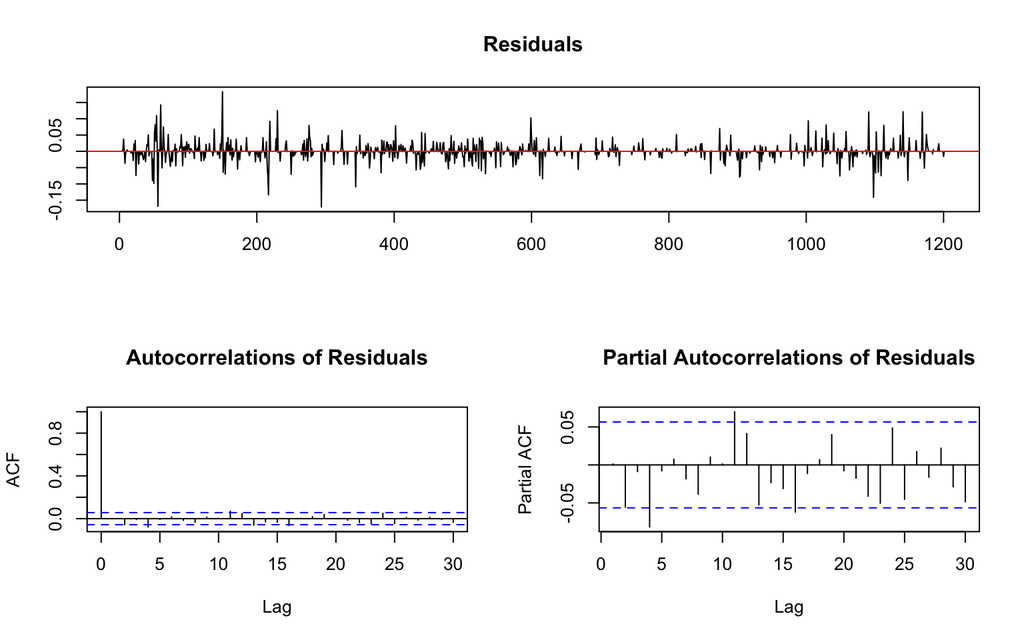

Les conclusions du test DF ne sont valables que s’il n’y a pas d’autocorrélation. Or, ici, les aléas sont autocorrélés donc notre conclusion n’est pas valide. **Nous devons donc effectuer le test de Dickey-Fuller Augmenté (ADF)**.

### Dickey-Fuller Augmenté (ADF)

Le test ADF correspond à un test DF avec des variables explicatives en plus qui représentent la variable retardée jusqu’à l’ordre P :

$$\Delta y_t = (\rho - 1) y_{t-1} + \sum_{p=1}^{P} \gamma_p \Delta y_{t-p}
+ \epsilon_t$$

La valeur de Pmax est calculée par la formule de Schwert (1989) : $[12 \times (T/100)^0,25]$

```
## Le critère de Schwert est calculé comme étant égal à 22 .
```

#### • MAIC

$$MAIC(p) = \ln(\hat{\sigma}^2_p) + 2 \frac{(\tau_T(p)+p)}{T-Pmax}$$

```
## Augmented DF test
##                                                 ADF test
## t-test statistic:                          -3.354574e+01
## p-value:                                    6.560879e-26
## Max lag of the diff. dependent variable:    0.000000e+00
##
## Call:
## dynlm(formula = formula(model), start = obs.1, end = obs.T)
##
## Residuals:
##       Min        1Q    Median        3Q       Max
## -0.170958 -0.000622  0.000000  0.000451  0.182989
##
## Coefficients:
##         Estimate Std. Error t value Pr(>|t|)
## L(y, 1) -0.97586    0.02909  -33.55   <2e-16 ***
## ---
## Signif. codes:  0 '***' 0.001 '**' 0.01 '*' 0.05 '.' 0.1 ' ' 1
##
## Residual standard error: 0.02452 on 1181 degrees of freedom
## Multiple R-squared:  0.4879, Adjusted R-squared:  0.4875
## F-statistic:    NA on NA and NA DF,  p-value: NA
```

On trouve `“Max lag of the diff.dependent variable”` = 0, on doit donc faire le BIC.

#### • BIC

```
## Augmented DF test
##                                                 ADF test
## t-test statistic:                          -3.354574e+01
## p-value:                                    6.560879e-26
## Max lag of the diff. dependent variable:    0.000000e+00
##
## Call:
## dynlm(formula = formula(model), start = obs.1, end = obs.T)
##
## Residuals:
##       Min        1Q    Median        3Q       Max
## -0.170958 -0.000622  0.000000  0.000451  0.182989
##
## Coefficients:
##         Estimate Std. Error t value Pr(>|t|)
## L(y, 1) -0.97586    0.02909  -33.55   <2e-16 ***
## ---
## Signif. codes:  0 '***' 0.001 '**' 0.01 '*' 0.05 '.' 0.1 ' ' 1
##
## Residual standard error: 0.02452 on 1181 degrees of freedom
## Multiple R-squared:  0.4879, Adjusted R-squared:  0.4875
## F-statistic:    NA on NA and NA DF,  p-value: NA
```

On trouve `“Max lag of the diff.dependent variable”` = 0, on doit donc partir de la valeur de Schwert.

*COURS :* Si le MAIC et le BIC vous donnent `pmax = 0`, alors vous allez introduite pmax variables explicatives additionnelles dans la régression puis ôtez un par un les $\gamma$ qui ne sont pas significatifs jusqu’à aboutir à un modèle où le dernier $\gamma$ est significatif sachant qu’on s’accorde à dire que $\gamma$ est significatif si la valeur absolue de sa statistique $t >1.6$. Vous pouvez ainsi aboutir à un modèle avec `lag=3` car $\gamma_1$ ni $\gamma_2$ ne le sont :

```r
summary(ur.df(rtt,type= "none",lags=Schwert))
```

```
##
## ###############################################
## # Augmented Dickey-Fuller Test Unit Root Test #
## ###############################################
##
## Test regression none
##
##
## Call:
## lm(formula = z.diff ~ z.lag.1 - 1 + z.diff.lag)
##
## Residuals:
##       Min        1Q    Median        3Q       Max
## -0.169793 -0.004478 -0.000105  0.004098  0.178168
##
## Coefficients:
##              Estimate Std. Error t value Pr(>|t|)
## z.lag.1      -1.33127    0.15954  -8.344   <2e-16 ***
## z.diff.lag1   0.34663    0.15533   2.232   0.0258 *
## z.diff.lag2   0.29026    0.15133   1.918   0.0553 .
## z.diff.lag3   0.28644    0.14726   1.945   0.0520 .
## z.diff.lag4   0.21288    0.14316   1.487   0.1373
## z.diff.lag5   0.20894    0.13855   1.508   0.1318
## z.diff.lag6   0.21328    0.13375   1.595   0.1111
## z.diff.lag7   0.19445    0.12886   1.509   0.1316
## z.diff.lag8   0.15166    0.12426   1.221   0.2225
## z.diff.lag9   0.15912    0.11970   1.329   0.1840
## z.diff.lag10  0.16028    0.11518   1.392   0.1643
## z.diff.lag11  0.23044    0.11097   2.077   0.0381 *
## z.diff.lag12  0.26628    0.10636   2.503   0.0124 *
## z.diff.lag13  0.21025    0.10095   2.083   0.0375 *
## z.diff.lag14  0.18493    0.09510   1.945   0.0521 .
## z.diff.lag15  0.15332    0.08871   1.728   0.0842 .
## z.diff.lag16  0.09145    0.08229   1.111   0.2667
## z.diff.lag17  0.08268    0.07548   1.095   0.2736
## z.diff.lag18  0.08634    0.06794   1.271   0.2040
## z.diff.lag19  0.12120    0.05950   2.037   0.0419 *
## z.diff.lag20  0.10974    0.05109   2.148   0.0319 *
## z.diff.lag21  0.08940    0.04104   2.178   0.0296 *
## z.diff.lag22  0.04824    0.02928   1.648   0.0997 .
## ---
## Signif. codes:  0 '***' 0.001 '**' 0.01 '*' 0.05 '.' 0.1 ' ' 1
##
## Residual standard error: 0.02435 on 1159 degrees of freedom
## Multiple R-squared:  0.5044, Adjusted R-squared:  0.4946
## F-statistic: 51.29 on 23 and 1159 DF,  p-value: < 2.2e-16
##
##
## Value of test-statistic is: -8.3444
##
## Critical values for test statistics:
##       1pct  5pct 10pct
## tau1 -2.58 -1.95 -1.62
```

Le dernier coefficient est supérieur à 1.6, c’est donc significatif. De plus, comme la statistique de test de -8.34 est bien plus basse que la valeur critique au seuil de 5 %, nous pouvons rejeter l’hypothèse nulle de racine unitaire (non-stationnarité). Sur la base des résultats du test ADF, il semble que **la série `rtt` testée est stationnaire**.

### Zivot et Andrews (ZA)

Ici, nous réalisons la méthode décrite par Perron en 1989 qui consiste à partir de la forme de Schwert puis de diminuer le nombre de $\gamma$ de telle sorte que le dernier ait une statistique t en valeur absolue < 1.6 et l’avant dernier une statistique t en valeur absolue supérieure 1.6 :

$$H_0 : \rho = 1 \quad vs \quad H_a : |\rho| < 1 \$$

```r
summary(ur.za(rtt, model="both",lag=22))
summary(ur.za(rtt, model="both",lag=21))
summary(ur.za(rtt, model="both",lag=20))
summary(ur.za(rtt, model="both",lag=19))
summary(ur.za(rtt, model="both",lag=18))
summary(ur.za(rtt, model="both",lag=17))
```

```r
summary(ur.za(rtt, model="both",lag=16))
```

```
##
## ################################
## # Zivot-Andrews Unit Root Test #
## ################################
##
##
## Call:
## lm(formula = testmat)
##
## Residuals:
##       Min        1Q    Median        3Q       Max
## -0.167786 -0.003911  0.000293  0.004179  0.169155
##
## Coefficients:
##               Estimate Std. Error t value Pr(>|t|)
## (Intercept) -9.817e-03  4.828e-03  -2.034  0.04223 *
## y.l1        -3.723e-01  1.383e-01  -2.691  0.00722 **
## trend        1.367e-04  4.884e-05   2.798  0.00522 **
## y.dl1        3.811e-01  1.330e-01   2.866  0.00423 **
## y.dl2        3.171e-01  1.281e-01   2.476  0.01343 *
## y.dl3        3.014e-01  1.231e-01   2.448  0.01451 *
## y.dl4        2.171e-01  1.183e-01   1.836  0.06668 .
## y.dl5        2.049e-01  1.136e-01   1.804  0.07148 .
## y.dl6        2.033e-01  1.085e-01   1.874  0.06120 .
## y.dl7        1.836e-01  1.026e-01   1.789  0.07388 .
## y.dl8        1.391e-01  9.642e-02   1.442  0.14950
## y.dl9        1.409e-01  8.966e-02   1.571  0.11643
## y.dl10       1.332e-01  8.284e-02   1.608  0.10817
## y.dl11       1.881e-01  7.570e-02   2.485  0.01309 *
## y.dl12       2.134e-01  6.795e-02   3.141  0.00173 **
## y.dl13       1.480e-01  5.941e-02   2.491  0.01289 *
## y.dl14       1.165e-01  5.090e-02   2.289  0.02225 *
## y.dl15       8.041e-02  4.087e-02   1.968  0.04936 *
## y.dl16       1.444e-02  2.915e-02   0.495  0.62053
## du          -1.400e-02  4.438e-03  -3.155  0.00164 **
## dt          -1.352e-04  4.888e-05  -2.766  0.00576 **
## ---
## Signif. codes:  0 '***' 0.001 '**' 0.01 '*' 0.05 '.' 0.1 ' ' 1
##
## Residual standard error: 0.02426 on 1167 degrees of freedom
##   (17 observations deleted due to missingness)
## Multiple R-squared:  0.03532,    Adjusted R-squared:  0.01879
## F-statistic: 2.136 on 20 and 1167 DF,  p-value: 0.00254
##
##
## Teststatistic: -9.9214
## Critical values: 0.01= -5.57 0.05= -5.08 0.1= -4.82
##
## Potential break point at position: 164
```

On voit que :

- La statistique t en valeur absolue de $𝛾15 = 1.967 > 1,6$
- La statistique t en valeur absolue de $𝛾16 = 0.495 < 1,6$
- les coefficients $δ1$ et $δ2$ sont significatifs (ici `du` et `dt`)

**Cela pourrait nous amener à penser que le PGD est TS avec un changement structurel**. Cependant, cette conclusion ne peut pas être tirée de manière définitive. Il est aussi envisageable que le PGD soit DS avec un changement structurel.

La date de rupture est la 164e observation qui correspond à la date :

```
## [1] "2013-08-27"
```

Nous pouvons constater la date de rupture sur le graphique ci-dessous :

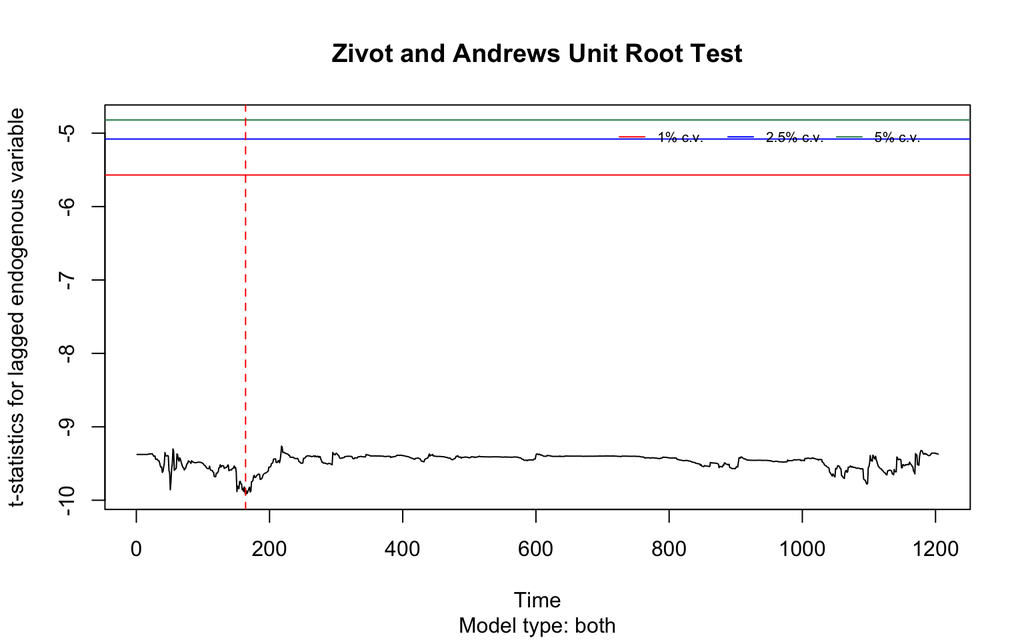

> La date de rupture étant le 27 août 2013, nous nous sommes intéressés à l’actualité de l’époque chez Square Enix. Square Enix a connu une phase difficile entre 2010 et 2013, mais en 2013, la société a commencé à voir des signes de redressement. La hausse en août 2013 peut être attribuée à l’anticipation de la sortie imminente de “Final Fantasy XIV: A Realm Reborn”, qui a été relancé le 27 août 2013. Le jeu était attendu avec impatience après l’échec de la version initiale, et la réception positive du relancement a probablement contribué à la hausse de l’action. Cela a marqué un tournant dans la réputation de Square Enix, qui commençait à regagner la confiance des joueurs et des investisseurs.

### Lee et Strazicich (LS)

Le test de Lee et Strazicich est une généralisation du test de racine unitaire de Schmidt et Phillips (SP). Ils ont généralisé le test SP en employant la classification des changements structurels de Perron (1989) ”crash” et ”both” sachant qu’ils les appellent respectivement ”crash”et ”break” et en introduisant 2 dates de rupture endogènes. Le mod`ele est le suivant :

$$y_t = \delta' Z_t + e_t
e_t = \beta e_{t-1} + \varepsilon_t$$

avec $\varepsilon \sim \mathcal{N}(0,\sigma^2)$ et $Z$ la matrice des variables exogènes.

Soit $T_{B1}$ la date du premier changement structurel et $T_{B2}$ la date du second.

- ”crash” : $Z_t = [\iota, tendance, DU_{1t}, DU_{2t}]'$ avec $DU_{jt} = 1$ si $t≥T_{Bj} + 1$ pour $j=1,2$ et $0$ sinon
- ”break” : $Z_t = [\iota, tendance, DU_{1t}, DU_{2t}, DT_{1t} , DT_{2t}]'$ avec $DT_{jt} = t- T_{Bj}$ si $t≥T_{Bj} + 1$ pour $j=1,2$ et $0$ sinon

Pour **“crash”**, nous testons :

Pour **“break”**, nous testons :

Notons que dans tous les cas, le PGD comprend des changements structurels sous H0 et sous Ha.

Le test LS peut s’effectuer avec ou sans boostrap. Dans notre cas, nous n’utiliserons pas boostrap car ce dernier est employé lorsque nous avons un faible nombre d’observation. Ce qui n’est pas le cas pour notre sére `rtt` (nombre de jour supérieur à 100).

```
## [1] -9.664604
## [1] "First possible structural break at position: 348"
## [1] "The location of the first break - lambda_1: 0.3 , with the number of total observations: 1205"
## Critical values - Crash model:
##          1%     5%    10%
## [1,] -4.239 -3.566 -3.211
## [1] "Number of lags determined by general-to-specific lag selection: 15"
## Runtime:
## Time difference of 0.1646771 mins
```

`First possible structural break at position: 348`

Cette position correspond à la date :

```
## [1] "2014-05-21"
```

> La date de rupture étant le 21 mai 2014, nous nous sommes intéressés à l’actualité de l’époque chez Square Enix. Cette période correspond à un léger creux après les premiers signes de redressement de Square Enix, probablement à la suite de résultats financiers ou d’événements particuliers. Il n’y a pas eu de gros titres ou de jeux majeurs autour de mai 2014, ce qui pourrait indiquer que la baisse est liée à une correction du marché après une montée précédente (comme celle de janvier 2014 évoqué précédemment) ou des attentes moins élevées pour les jeux à venir. Les résultats financiers publiés à cette période auraient pu décevoir, malgré le succès des titres de 2013.

De plus, le PGD ne peut pas être TS puisque nous avons vu qu’il n’y a pas de tendance. **La conclusion est que le PGD qui a généré notre série est stationnaire avec une date de rupture en mai 2014**.

# Conclusion

Pour conclure, nous pouvons faire un tableau récapitulatif des résultats pour les 8 caractéristiques de nos séries `rte` et `rtt` :

Tableau récapitulatif des caractéristiques pour RTE et RTT

|  | RTE | RTT |
| --- | --- | --- |
| 1. Asymétrie perte / gain | OUI | NON |
| 2. Queues de distribution épaisses | OUI P>G | OUI P=G |
| 3. Autocorrélations des carrés des rendements | NON | OUI |
| 4. Clusters de volatilité | OUI | OUI |
| 5. Queues épaisses conditionnelles | OUI | OUI |
| 6. Effet de levier | OUI | OUI |
| 7. Saisonnalité | OUI | OUI |
| 8. Stationnarité | OUI | OUI |